# Comparing Models with tourr

## Overview

The `tourr` package generates animated sequences of linear projections (called a *grand tour*) that collectively show the structure of high-dimensional data from many angles. When combined with `classbound`, you can visualize how decision boundaries of different classifiers appear across multiple projection angles.

The key principle is to generate **one shared projection sequence** and apply it to **all models**. This ensures that when you compare boundaries side by side, each model is viewed through the exact same projection at the exact same frame.

```r
# Install tourr if needed
install.packages("tourr")
```

## Workflow overview

```
1. Prepare data (numeric features only)
2. Fit models
3. Generate one tour path via tourr::save_history()
4. For each tour frame (projection basis):
   a. Compute boundary via boundary_compute(..., projection = list(basis = frame))
   b. Forward-project observations for overlay
   c. Plot with plot_boundary()
5. Compare across models at the same frame
```

## Step 1: Prepare data

We use the `data69_1` dataset: 5000 observations with 21 numeric features and 3 classes. For this example we work with a subset of 300 observations and 5 features to keep computation fast.

```r
e <- new.env(parent = emptyenv())
data("data69_1", package = "classbound", envir = e)
data69_1 <- e$data69_1

# Work with a fast subset
d <- data69_1[1:300, c("Y", "V1", "V2", "V3", "V4", "V5")]
d$Y <- as.factor(d$Y)
feat_cols <- c("V1", "V2", "V3", "V4", "V5")
```

## Step 2: Fit models on the same data

All models must be trained on the same features and class levels.

```r
m_rpart <- fit_model(d, Y ~ ., rpart::rpart)
m_rf <- fit_model(d, Y ~ ., randomForest::randomForest, interface = "matrix")
```

## Step 3: Generate one shared projection sequence

`tourr::save_history()` computes a sequence of orthonormal bases (tour frames) for the specified feature space. Each frame is a `p × 2` matrix defining a 2D projection.

```r
# Standardize the features before touring
x_std <- scale(d[, feat_cols])
center_vals <- attr(x_std, "scaled:center")
scale_vals <- attr(x_std, "scaled:scale")
x_std <- as.data.frame(x_std)

if (requireNamespace("tourr", quietly = TRUE)) {
  set.seed(42)
  tour_history <- tourr::save_history(
    x_std,
    tour_path = tourr::grand_tour(d = 2),
    max_bases = 5 # 5 tour frames for this example
  )
}
```

```
#> Converting input data to the required matrix format.
```

## Step 4: Visualize at one tour frame

Each element of `tour_history` is a `p × 2` orthonormal basis matrix. Extract a frame, construct the projection list, compute the boundary for each model, and plot.

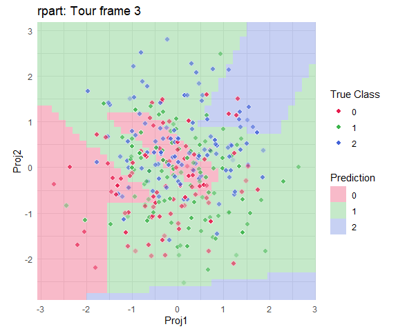

```r
if (requireNamespace("tourr", quietly = TRUE) && exists("tour_history")) {
  # Use frame 3 as an example
  frame_idx <- 3
  basis <- matrix(tour_history[, , frame_idx], nrow = length(feat_cols), ncol = 2)
  rownames(basis) <- feat_cols

  proj_list <- list(basis = basis, center = center_vals, scale = scale_vals)

  # Forward-project the training data to get axis ranges
  x_mat <- scale(d[, feat_cols], center = center_vals, scale = scale_vals)
  z_mat <- x_mat %*% basis
  ranges <- list(
    Proj1 = range(z_mat[, 1]) + c(-0.3, 0.3),
    Proj2 = range(z_mat[, 2]) + c(-0.3, 0.3)
  )
  colnames(basis) <- c("Proj1", "Proj2")
  proj_list$basis <- basis

  # Compute boundary for rpart at this frame
  b_rpart <- boundary_compute(m_rpart,
    feature_range = ranges, resolution = 40,
    projection = proj_list
  )
  plot_boundary(b_rpart,
    obs_data = d, true_label = "Y",
    x_col = "Proj1", y_col = "Proj2"
  ) +
    ggplot2::ggtitle("rpart: Tour frame 3")
}
```

## Step 5: Compare models at the same frame

Because both models are visualized using the same projection, the regions are directly comparable.

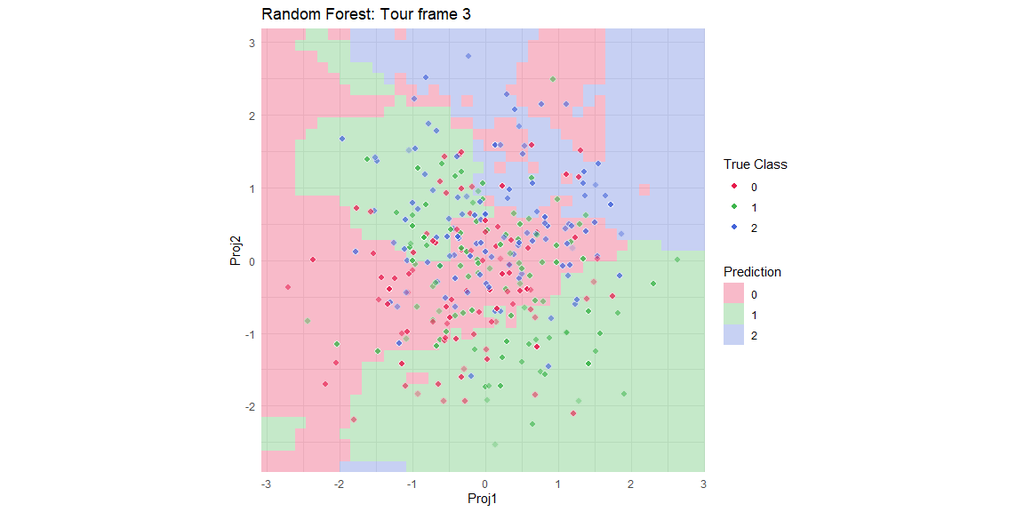

```r
if (requireNamespace("tourr", quietly = TRUE) && exists("tour_history")) {
  b_rf <- boundary_compute(m_rf,
    feature_range = ranges, resolution = 40,
    projection = proj_list
  )
  plot_boundary(b_rf,
    obs_data = d, true_label = "Y",
    x_col = "Proj1", y_col = "Proj2"
  ) +
    ggplot2::ggtitle("Random Forest: Tour frame 3")
}
```

## Animating the tour (optional)

To create an animated tour, iterate over all frames and display each plot in sequence. In an interactive R session you can use `tourr::animate()` directly with custom display functions, or save individual frames and combine them with the `animation` or `gganimate` packages.

```r
# Pseudocode (adapt based on your animation workflow)
for (i in seq_len(dim(tour_history)[3])) {
  basis_i <- matrix(tour_history[, , i], nrow = length(feat_cols), ncol = 2)
  rownames(basis_i) <- feat_cols
  colnames(basis_i) <- c("Proj1", "Proj2")
  proj_i <- list(basis = basis_i, center = center_vals, scale = scale_vals)

  b <- boundary_compute(m_rpart,
    feature_range = ranges, resolution = 40,
    projection = proj_i
  )
  p <- plot_boundary(b,
    obs_data = d, true_label = "Y",
    x_col = "Proj1", y_col = "Proj2"
  )
  print(p)
}
```

## Key points

- Generate one tour path; reuse it for every model.
- All models must be trained on the same set of numeric features.
- Use `rownames(basis) <- feat_cols` and `colnames(basis) <- c("Proj1", "Proj2")` to match the feature order expected by `boundary_compute()`.
- The `center` and `scale` vectors reverse any standardization applied before touring, ensuring the boundary grid is mapped back to the correct feature space.